# Amazon Copurchased

This is a Python notebook created using "jupyter".

Author: Rafael J. P. dos Santos

## Parameters

We use the parameter below to set the maximum number of edges to be read from the CSV containing edges (links).

```python
max_edges = 500000 # Set quantity to read from file
edges_csv_file = "data/20180812_links"
nodes_csv_file = "data/20180812_nodes"
```

## Load the libraries

Let's load the Python libraries that we will need throughout the script

```python
import networkx as nx
import matplotlib.pyplot as plt
import pandas as pd
from sklearn.model_selection import train_test_split
import numpy as np
from sklearn.tree import export_graphviz
import pydot
from sklearn.ensemble import RandomForestRegressor
from __future__ import division
import sklearn
#from sklearn.cross_validation import cross_val_score
from sklearn.model_selection import cross_validate
from sklearn.metrics import make_scorer
import hashlib
import sys
print('The scikit-learn version is {}.'.format(sklearn.__version__))
```

```
The scikit-learn version is 0.20.2.
```

## Read graph

### Read only first lines of datafile

Due to slowness in calculating centrality measures, we use the parameter provided in the beggining of the script to limit the number of edges we will read.

```python
lines = []
total_line_count = 0
with open(edges_csv_file, 'rb') as f:
    f.readline()   # skip first line / header
    while True:
        line = f.readline()
        if not line:
            break
        if not (max_edges > 0 and len(lines) >= max_edges):
            lines.append(line)
        total_line_count += 1
G = nx.parse_edgelist(lines, delimiter=',', nodetype=int)
```

```python
print "Using %d edges out of %d available (%.2f%% of data)" % (len(lines), total_line_count, len(lines)/total_line_count * 100)
```

```
Using 229338 edges out of 229338 available (100.00% of data)
```

### Calculate nodes centrality measures

Now that we have our NetworkX graph, let's calculate some centrality measures for every node.

```python
centrality_measures = {}
```

#### Degree

```python
centrality_measures["degree"] = nx.degree(G)
```

#### Eigenvector centrality

```python
centrality_measures["eigenvector_centrality"] = nx.eigenvector_centrality_numpy(G)
```

#### Approximate betweenness centrality (current flow)

```python
centrality_measures["betweenness_centrality"] = nx.approximate_current_flow_betweenness_centrality(G)
```

#### Closeness centrality

```python
# Very slow!
centrality_measures["closeness_centrality"] = nx.closeness_centrality(G)
```

#### Betweenness centrality

```python
# Very slow!
centrality_measures["betweenness_centrality"] = nx.betweenness_centrality(G)
```

### Load node properties

Let's load the CSV containing the nodes data (title, price) into a Pandas dataframe, and append the centrality measures calculated above.

```python
df = pd.read_csv(nodes_csv_file)
```

#### Convert ID to random int to avoid leaking knowledge

```python
sha256_ids = df['id'].map(lambda x: int(hashlib.sha256(str(x)).hexdigest()[0:8], 16))
```

```python
# Add columns to dataframe
def merge_columns(dataframe, data):
    df = dataframe.copy()
    for col in data:
        rows = []
        for item in data[col].items():
            rows.append({"id": item[0], col: item[1]})
        df = df.merge(pd.DataFrame(rows))
    return df

df = merge_columns(df, centrality_measures)
df = merge_columns(df, {'sha256_id': sha256_ids})
```

### Let's convert some fields to numeric

```python
categorical_features = [
    #'category1',
    #'category2',
    #'category3',
    #'category4',
    #'category5',
    #'category6',
    #'category7',
    #'category8',
    #'category9',
    #'category10',
    #'language',
    #'coverType',
    #'publisher',
    #'rankingCategory',
    #'authors'
]

numeric_features = [
    'degree',
    'eigenvector_centrality',
    'betweenness_centrality',
    #'ranking',
    #'reviewCount',
    #'pages',
    #'weight',
    #'height',
    #'width',
    #'depth',
    #'rating'
]

df = df.replace("<<MISSING_DATA>>", np.NaN)
df[numeric_features] = df[numeric_features].apply(pd.to_numeric)
df[['price']] = df[['price']].apply(pd.to_numeric)

for feature in numeric_features:
    df[feature].fillna(df[feature].mean(), inplace = True)
```

### Remove nodes without price

```python
df = df.drop(df[df["price"].isnull()].index)
#df = df.drop(df[df["price"] > 500].index)
```

### Inspect columns

```python
df.columns
```

```
Index([u'id', u'title', u'url', u'authors', u'coverType', u'publisher',
       u'edition', u'publicationDate', u'rankingCategory', u'category1',
       u'category2', u'category3', u'category4', u'category5', u'category6',
       u'category7', u'category8', u'category9', u'category10', u'isbn10',
       u'isbn13', u'language', u'postProcessed', u'price', u'ranking',
       u'pages', u'reviewCount', u'rating', u'width', u'height', u'depth',
       u'weight', u'eigenvector_centrality', u'degree',
       u'betweenness_centrality', u'sha256_id'],
      dtype='object')
```

### Features summary

Below we have a summary of the Pandas dataframe. We can see the number of nodes that we are actually analyzing, which depends on the max_edges parameter defined before.

```python
pd.set_option('display.max_columns', None)
#df.describe(include='all')
df.describe(include='all', percentiles=[0.25, 0.5, 0.75, 0.85, 0.9, 0.95, 0.99])
```

|  | id | title | url | authors | coverType | publisher | edition | publicationDate | rankingCategory | category1 | category2 | category3 | category4 | category5 | category6 | category7 | category8 | category9 | category10 | isbn10 | isbn13 | language | postProcessed | price | ranking | pages | reviewCount | rating | width | … |
| --- | --- | --- | --- | --- | --- | --- | --- | --- | --- | --- | --- | --- | --- | --- | --- | --- | --- | --- | --- | --- | --- | --- | --- | --- | --- | --- | --- | --- | --- | --- |
| count | 9153.000000 | 9153 | 9153 | 9152 | 9035 | 9052 | 0.0 | 783 | 8820 | 8707 | 8707 | 6525 | 3345 | 1205 | 188 | 17 | 0.0 | 0.0 | 0.0 | 9055 | 9055 | 9050 | 9153.0 | 9153.000000 | 8820 | 9035 | 6189 | 6189 | 9018 | … |
| unique | NaN | 8952 | 9153 | 6177 | 11 | 728 | NaN | 574 | 1 | 1 | 28 | 228 | 440 | 309 | 71 | 8 | NaN | NaN | NaN | 9055 | 9055 | 7 | NaN | NaN | 8306 | 766 | 195 | 35 | 166 | … |
| top | NaN | Macroeconomia | https://www.amazon.com.br/dp/8580332990/ | Vários Autores (Autor) | Capa comum | Companhia das Letras | NaN | 1 de janeiro de 2014 | Livros | Livros | Política, Filosofia e Ciências Sociais | Filosofia | Matemática | Brasil | Probabilidade e Estatística | Neurociência | NaN | NaN | NaN | 8525431494 | 978-8582600481 | Português | NaN | NaN | 38789 | 160 | 1 | 5.0 | 15.6 | … |
| freq | NaN | 6 | 1 | 106 | 7729 | 536 | NaN | 13 | 8820 | 8707 | 1557 | 914 | 165 | 78 | 18 | 4 | NaN | NaN | NaN | 1 | 1 | 7976 | NaN | NaN | 4 | 216 | 1498 | 2138 | 644 | … |
| mean | 4896.658473 | NaN | NaN | NaN | NaN | NaN | NaN | NaN | NaN | NaN | NaN | NaN | NaN | NaN | NaN | NaN | NaN | NaN | NaN | NaN | NaN | NaN | 1.0 | 71.900469 | NaN | NaN | NaN | NaN | NaN | … |
| std | 2826.520995 | NaN | NaN | NaN | NaN | NaN | NaN | NaN | NaN | NaN | NaN | NaN | NaN | NaN | NaN | NaN | NaN | NaN | NaN | NaN | NaN | NaN | 0.0 | 145.716338 | NaN | NaN | NaN | NaN | NaN | … |
| min | 1.000000 | NaN | NaN | NaN | NaN | NaN | NaN | NaN | NaN | NaN | NaN | NaN | NaN | NaN | NaN | NaN | NaN | NaN | NaN | NaN | NaN | NaN | 1.0 | 2.900000 | NaN | NaN | NaN | NaN | NaN | … |
| 25% | 2481.000000 | NaN | NaN | NaN | NaN | NaN | NaN | NaN | NaN | NaN | NaN | NaN | NaN | NaN | NaN | NaN | NaN | NaN | NaN | NaN | NaN | NaN | 1.0 | 26.310000 | NaN | NaN | NaN | NaN | NaN | … |
| 50% | 4900.000000 | NaN | NaN | NaN | NaN | NaN | NaN | NaN | NaN | NaN | NaN | NaN | NaN | NaN | NaN | NaN | NaN | NaN | NaN | NaN | NaN | NaN | 1.0 | 39.110000 | NaN | NaN | NaN | NaN | NaN | … |
| 75% | 7348.000000 | NaN | NaN | NaN | NaN | NaN | NaN | NaN | NaN | NaN | NaN | NaN | NaN | NaN | NaN | NaN | NaN | NaN | NaN | NaN | NaN | NaN | 1.0 | 63.110000 | NaN | NaN | NaN | NaN | NaN | … |
| 85% | 8326.200000 | NaN | NaN | NaN | NaN | NaN | NaN | NaN | NaN | NaN | NaN | NaN | NaN | NaN | NaN | NaN | NaN | NaN | NaN | NaN | NaN | NaN | 1.0 | 90.572000 | NaN | NaN | NaN | NaN | NaN | … |
| 90% | 8813.800000 | NaN | NaN | NaN | NaN | NaN | NaN | NaN | NaN | NaN | NaN | NaN | NaN | NaN | NaN | NaN | NaN | NaN | NaN | NaN | NaN | NaN | 1.0 | 120.744000 | NaN | NaN | NaN | NaN | NaN | … |
| 95% | 9294.400000 | NaN | NaN | NaN | NaN | NaN | NaN | NaN | NaN | NaN | NaN | NaN | NaN | NaN | NaN | NaN | NaN | NaN | NaN | NaN | NaN | NaN | 1.0 | 193.970000 | NaN | NaN | NaN | NaN | NaN | … |
| 99% | 9671.480000 | NaN | NaN | NaN | NaN | NaN | NaN | NaN | NaN | NaN | NaN | NaN | NaN | NaN | NaN | NaN | NaN | NaN | NaN | NaN | NaN | NaN | 1.0 | 723.754400 | NaN | NaN | NaN | NaN | NaN | … |
| max | 9770.000000 | NaN | NaN | NaN | NaN | NaN | NaN | NaN | NaN | NaN | NaN | NaN | NaN | NaN | NaN | NaN | NaN | NaN | NaN | NaN | NaN | NaN | 1.0 | 2531.070000 | NaN | NaN | NaN | NaN | NaN | … |

Below we can inspect the first rows of data, containing title, price, degree and other centrality measures.

```python
df.head(10)
```

|  | id | title | url | authors | coverType | publisher | edition | publicationDate | rankingCategory | category1 | category2 | category3 | category4 | category5 | category6 | category7 | category8 | category9 | category10 | isbn10 | isbn13 | language | postProcessed | price | ranking | pages | reviewCount | rating | width | … |
| --- | --- | --- | --- | --- | --- | --- | --- | --- | --- | --- | --- | --- | --- | --- | --- | --- | --- | --- | --- | --- | --- | --- | --- | --- | --- | --- | --- | --- | --- | --- |
| 0 | 1 | The Stanford Mathematics Problem Book: With Hi... | https://www.amazon.com.br/dp/0486469247/ | George Polya (Autor), | Capa comum | Dover Publications | NaN | 19 de fevereiro de 2009 | Livros | Livros | Inglês e Outras Línguas | Ciências Tecnológicas | Matemática | Estudo e Ensino | NaN | NaN | NaN | NaN | NaN | 0486469247 | 978-0486469249 | Inglês | 1 | 26.25 | 59183 | 68 | 1 | 4.0 | 14 | … |
| 1 | 2 | Fourier Series | https://www.amazon.com.br/dp/0486633179/ | Georgi P. Tolstov (Autor), | Capa comum | Dover Publications | NaN | 1 de junho de 1976 | Livros | Livros | Inglês e Outras Línguas | Ciências Tecnológicas | Matemática | Aplicada | Probabilidade e Estatística | NaN | NaN | NaN | NaN | 0486633179 | 978-0486633176 | Inglês | 1 | 50.37 | 56112 | 352 | 3 | 4.6 | 14.6 | … |
| 2 | 3 | Probability Theory: A Concise Course | https://www.amazon.com.br/dp/0486635449/ | Y. A. Rozanov (Autor), | Capa comum | Dover Publications | NaN | NaN | Livros | Livros | Inglês e Outras Línguas | Ciências Tecnológicas | Matemática | Aplicada | Probabilidade e Estatística | NaN | NaN | NaN | NaN | 0486635449 | 978-0486635446 | Inglês | 1 | 29.23 | 44345 | 160 | NaN | NaN | 14.4 | … |
| 3 | 4 | Vectors, Tensors and the Basic Equations of Fl... | https://www.amazon.com.br/dp/0486661105/ | Rutherford Aris (Autor), | Capa comum | Dover Publications | NaN | NaN | Livros | Livros | Inglês e Outras Línguas | Engenharia e Transporte | Engenharia | Mecânica | Hidráulica | NaN | NaN | NaN | NaN | 0486661105 | 978-0486661100 | Inglês | 1 | 48.79 | 82275 | 320 | 2 | 4.5 | 13.7 | … |
| 4 | 5 | Ordinary Differential Equations | https://www.amazon.com.br/dp/0486649407/ | Morris Tenenbaum (Autor), | Capa comum | Dover Publications | NaN | NaN | Livros | Livros | Inglês e Outras Línguas | Ciências Tecnológicas | Matemática | Aplicada | Equações Diferenciais | NaN | NaN | NaN | NaN | 0486649407 | 978-0486649405 | Inglês | 1 | 71.63 | 40840 | 848 | 4 | 4.5 | 13.8 | … |
| 5 | 6 | The Variational Principles of Mechanics | https://www.amazon.com.br/dp/0486650677/ | Cornelius Lanczos (Autor), | Capa comum | Dover Publications | NaN | NaN | Livros | Livros | Inglês e Outras Línguas | Ciências Tecnológicas | Física | Mecânica | NaN | NaN | NaN | NaN | NaN | 0486650677 | 978-0486650678 | Inglês | 1 | 88.15 | 36960 | 418 | 1 | 5.0 | 13.8 | … |
| 6 | 7 | A First Look at Perturbation Theory | https://www.amazon.com.br/dp/0486675513/ | James G. Simmonds (Autor) | Capa comum | Dover Publications Inc. | NaN | NaN | Livros | Livros | Inglês e Outras Línguas | Ciências Tecnológicas | Matemática | Aplicada | Equações Diferenciais | NaN | NaN | NaN | NaN | 0486675513 | 978-0486675510 | Inglês | 1 | 36.10 | 37291 | 160 | NaN | NaN | 13.7 | … |
| 7 | 8 | Thermodynamics and the Kinetic Theory of Gases... | https://www.amazon.com.br/dp/0486414612/ | Wolfgang Pauli (Autor), | Capa comum | Dover Publications | NaN | 18 de outubro de 2010 | Livros | Livros | Inglês e Outras Línguas | Ciências Tecnológicas | Física | Dinâmica | Termodinâmica | NaN | NaN | NaN | NaN | 0486414612 | 978-0486414614 | Inglês | 1 | 26.01 | 24406 | 160 | 2 | 5.0 | 13.8 | … |
| 8 | 9 | Mechanics | https://www.amazon.com.br/dp/0486607542/ | Jacob P. Den Hartog (Autor), | Capa comum | Dover Publications | NaN | 1 de junho de 1961 | Livros | Livros | Inglês e Outras Línguas | Ciências Tecnológicas | Física | Mecânica | NaN | NaN | NaN | NaN | NaN | 0486607542 | 978-0486607542 | Inglês | 1 | 50.96 | 90609 | 480 | NaN | NaN | 13.6 | … |
| 9 | 10 | Statistical Thermodynamics | https://www.amazon.com.br/dp/0486661016/ | Erwin Schrodinger (Autor), | Capa comum | Dover Publications | NaN | NaN | Livros | Livros | Inglês e Outras Línguas | Ciências Tecnológicas | Física | Dinâmica | Termodinâmica | NaN | NaN | NaN | NaN | 0486661016 | 978-0486661018 | Inglês | 1 | 32.16 | 65112 | 112 | NaN | NaN | 14 | … |

## Random forest using various features, price as target

### Preparing data

```python
df_with_dummies = pd.get_dummies(df[['sha256_id'] + numeric_features + categorical_features + ['price']],columns=categorical_features,drop_first=True)
```

```python
feature_list = list(df_with_dummies.drop(columns = ['price']))

features_values = np.array(df_with_dummies.drop(columns = ['price']))
target_value = np.array(df_with_dummies['price'])

features_and_target = np.concatenate((features_values, target_value.reshape(len(target_value), 1)), axis = 1)

#print features_and_target.shape

# Shuffle features_and_target
np.random.shuffle(features_and_target)

limit = int(round(len(target_value) * 0.8))
print "Test percentage", (len(target_value)-limit)/len(target_value)

features = features_and_target[:limit, :-1]
target = features_and_target[:limit, -1]

test_features = features_and_target[limit:, :-1]
test_target = features_and_target[limit: , -1]

print "Train features shape", features.shape
print "Train target shape", target.shape
print "Test features shape", test_features.shape
print "Test target shape", test_target.shape
```

```
Test percentage 0.200043701519
Train features shape (7322, 4)
Train target shape (7322,)
Test features shape (1831, 4)
Test target shape (1831,)
```

### Average price as baseline

It's important to have a baseline, so we can validate our predictions after running our model. One easy choice for baseline is the average price of a book.

```python
average_target = np.average(target)
print "Average price: R$", average_target
```

```
Average price: R$ 72.9866866976236
```

### Cross val

#### Run cross val

```python
def baseline_score_function (y_true, y_pred):
    errors_baseline = abs(average_target - y_true)
    return np.mean(errors_baseline)

def relative_error_function (y_true, y_pred):
    errors_absolute = abs(y_pred - y_true)
    errors_relative = errors_absolute / y_true
    return np.mean(errors_relative)

def baseline_relative_error_function (y_true, y_pred):
    errors_absolute = abs(average_target - y_true)
    errors_relative = errors_absolute / y_true
    return np.mean(errors_relative)

rf = RandomForestRegressor(n_estimators = 50, n_jobs = -1)

scorer = make_scorer(baseline_score_function)
scorer2 = make_scorer(relative_error_function)
scorer3 = make_scorer(baseline_relative_error_function)

scores = cross_validate(estimator=rf, X=features, y=target, cv=10,
                        scoring = {
                            'abs': 'neg_mean_absolute_error',
                            'baseline': scorer,
                            'relative': scorer2,
                            'baseline_relative': scorer3
                        },
                        return_train_score=False, return_estimator = True)

# Use best estimator to do some visual reports
rf = scores['estimator'][0]
```

#### Cross val score

```python
print "=== Relative"
print "RF relative abs mean: ", np.mean(np.abs(scores['test_relative']))
print "RF relative abs std: ", np.std(scores['test_relative'])

#print "Baseline: ", scores['test_baseline']
print "Baseline relative mean: ", np.mean(scores['test_baseline_relative'])
print "Baseline relative std: ", np.std(scores['test_baseline_relative'])

print "=== Absolute"

#print "Abs: ", scores['test_abs']
print "RF abs mean: ", np.mean(np.abs(scores['test_abs']))
print "RF abs std: ", np.std(scores['test_abs'])

#print "Baseline: ", scores['test_baseline']
print "Baseline mean: ", np.mean(scores['test_baseline'])
print "Baseline std: ", np.std(scores['test_baseline'])
```

```
=== Relative
RF relative abs mean:  0.9648803427706578
RF relative abs std:  0.06506589719805468
Baseline relative mean:  1.362338094973486
Baseline relative std:  0.07080310782756737
=== Absolute
RF abs mean:  51.467227544338336
RF abs std:  5.010263542695066
Baseline mean:  59.49579030079411
Baseline std:  4.475810748861607
```

#### List of most important features

```python
importance = zip(feature_list, rf.feature_importances_)
importance.sort(key=lambda x:-x[1])
pd.DataFrame(importance).head(200)
```

|  | 0 | 1 |
| --- | --- | --- |
| 0 | eigenvector_centrality | 0.290869 |
| 1 | betweenness_centrality | 0.279536 |
| 2 | sha256_id | 0.255145 |
| 3 | degree | 0.174449 |

## Test dataset and visual inspection

```python
test_predictions = rf.predict(test_features)
```

### Predicted price vs real price

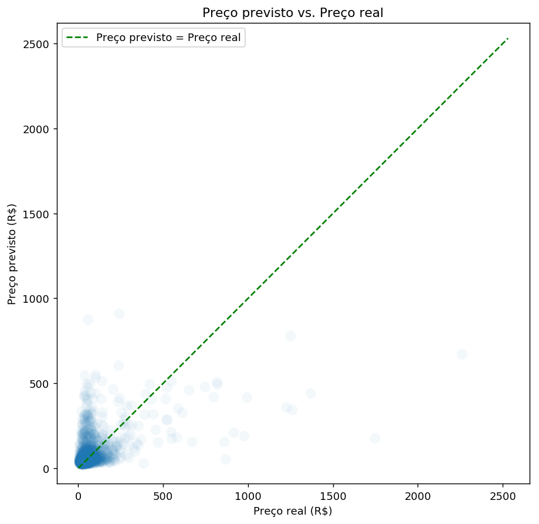

```python
plt.figure(figsize=(8,8), dpi=130)
plt.scatter(test_target, test_predictions, 100, alpha=0.05, edgecolors="none")
baseline = [0, np.max(target)]
plt.plot(baseline, baseline, "--", color="green", label = u"Preço previsto = Preço real")
ax = plt.gca()
ax.set_ylabel(u"Preço previsto (R$)")
ax.set_xlabel(u"Preço real (R$)")
ax.legend()
plt.title(u"Preço previsto vs. Preço real")
plt.axes().set_aspect('equal', 'datalim')
#plt.xlim(0, 150)
#plt.ylim(0, 150)
plt.show()
```

### Mean absolute error

Now we can compare the errors obtained by our predictions against the errors provided by the baseline (average price). Our prediction errors should be less than the baseline errors to consider the model successful.

```python
# Calculate the absolute errors
errors = abs(test_predictions - test_target)
errors_baseline = abs(average_target - test_target)
errors_relative = errors/test_target
errors_baseline_relative = errors_baseline/test_target
# Print out the mean absolute error (mae)
print "== Absolute"
print('Mean absolute prediction error: R$', round(np.mean(errors), 2))
print('Std prediction error: R$', round(np.std(errors), 2))
print('Mean absolute error using average: R$', round(np.mean(errors_baseline), 2))
print('Std prediction error using average: R$', round(np.std(errors_baseline), 2))
print "== Relative"
print('Mean relative absolute prediction error: ', round(np.mean(errors_relative), 2))
print('Std relative prediction error: ', round(np.std(errors_relative), 2))
print('Mean relative absolute error using average: ', round(np.mean(errors_baseline_relative), 2))
print('Std relative prediction error using average: ', round(np.std(errors_baseline_relative), 2))
```

```
== Absolute
('Mean absolute prediction error: R$', 46.74)
('Std prediction error: R$', 99.34)
('Mean absolute error using average: R$', 54.43)
('Std prediction error using average: R$', 111.22)
== Relative
('Mean relative absolute prediction error: ', 0.98)
('Std relative prediction error: ', 1.71)
('Mean relative absolute error using average: ', 1.37)
('Std relative prediction error using average: ', 1.58)
```

### Join data

```python
pd.set_option('display.max_columns', None)
data = {
    "all_features": test_features.tolist(),
    "sha256_id": test_features[:, 0],
    "target": test_target,
    "prediction": test_predictions,
    "error": errors,
    "error_relative": errors_relative,
    "error_baseline": errors_baseline,
    "error_baseline_relative": errors_baseline_relative
}
predicted_df = pd.DataFrame(data = data)
joined_predicted_df = predicted_df
joined_predicted_df = predicted_df.set_index("sha256_id").join(df.set_index("sha256_id"))
```

### Worst absolute predictions

Below we can inspect the rows with the biggest prediction error.

```python
joined_predicted_df.sort_values('error', ascending = False).head(20)
```

| sha256_id | all_features | error | error_baseline | error_baseline_relative | error_relative | prediction | target | id | title | url | authors | coverType | publisher | edition | publicationDate | rankingCategory | category1 | category2 | category3 | category4 | category5 | category6 | category7 | category8 | category9 | category10 | isbn10 | isbn13 | language | … |
| --- | --- | --- | --- | --- | --- | --- | --- | --- | --- | --- | --- | --- | --- | --- | --- | --- | --- | --- | --- | --- | --- | --- | --- | --- | --- | --- | --- | --- | --- | --- |
| 2.300254e+09 | [2300254391.0, 24.0, 5.67619962654e-07, 0.0008... | 1589.3198 | 2187.123313 | 0.967707 | 0.703205 | 670.7902 | 2260.11 | 2202 | Lehninger Principles of Biochemistry | https://www.amazon.com.br/dp/1464126119/ | David L. Nelson (Autor), | Capa dura | W. H. Freeman | NaN | NaN | Livros | Livros | Inglês e Outras Línguas | Ciências Tecnológicas | Ciências Biológicas | Bioquímica | NaN | NaN | NaN | NaN | NaN | 1464126119 | 978-1464126116 | Inglês | … |
| 2.082220e+09 | [2082219845.0, 7.0, 2.18781896824e-07, 0.00018... | 1572.2838 | 1675.473313 | 0.958257 | 0.899239 | 176.1762 | 1748.46 | 1706 | Numerical Mathematics and Computing | https://www.amazon.com.br/dp/1133103715/ | E. Ward Cheney (Autor), | Capa dura | Cengage Learning | NaN | NaN | NaN | NaN | NaN | NaN | NaN | NaN | NaN | NaN | NaN | NaN | NaN | 1133103715 | 978-1133103714 | Inglês | … |
| 1.159398e+09 | [1159397835.0, 32.0, 1.3572721774e-06, 0.00055... | 929.1562 | 1296.193313 | 0.946693 | 0.678622 | 440.0238 | 1369.18 | 1703 | Mathematical Statistics and Data Analysis [Wit... | https://www.amazon.com.br/dp/0534399428/ | John A. Rice (Autor) | Capa dura | Duxbury Resource Center | NaN | NaN | NaN | NaN | NaN | NaN | NaN | NaN | NaN | NaN | NaN | NaN | NaN | 8131519546 | 978-8131519547 | Inglês | … |
| 2.053427e+09 | [2053426754.0, 16.0, 1.88488637544e-06, 0.0003... | 917.4132 | 1187.563313 | 0.942099 | 0.727788 | 343.1368 | 1260.55 | 1686 | Statistics for Engineers and Scientists | https://www.amazon.com.br/dp/0073401331/ | William Cyrus Navidi (Autor) | Capa dura | McGraw-Hill Science/Engineering/Math | NaN | NaN | NaN | NaN | NaN | NaN | NaN | NaN | NaN | NaN | NaN | NaN | NaN | 0073401331 | 978-0073401331 | Inglês | … |
| 1.224607e+09 | [1224607329.0, 5.0, 4.37137908677e-08, 2.38951... | 868.2606 | 1152.943313 | 0.940464 | 0.708246 | 357.6694 | 1225.93 | 2176 | Introduction to Environmental Engineering and ... | https://www.amazon.com.br/dp/0131481932/ | Gilbert M. Masters (Autor), | Capa dura | Pearson | NaN | NaN | NaN | NaN | NaN | NaN | NaN | NaN | NaN | NaN | NaN | NaN | NaN | 0131481932 | 978-0131481930 | Inglês | … |
| 1.080225e+07 | [10802248.0, 2.0, 1.27280095161e-06, 1.6846795... | 816.8100 | 796.003313 | 0.916010 | 0.939953 | 52.1800 | 868.99 | 6595 | Macroeconomics: Imperfections, Institutions, a... | https://www.amazon.com.br/dp/0198776225/ | Wendy Carlin (Autor), | Capa comum | Oxford University Press, USA | NaN | 2 de fevereiro de 2006 | Livros | Livros | Inglês e Outras Línguas | Administração, Negócios e Economia | Economia | Macroeconomia | NaN | NaN | NaN | NaN | NaN | 0198776225 | 978-0198776222 | Inglês | … |
| 3.298496e+09 | [3298495980.0, 14.0, 2.96212988905e-07, 5.3782... | 816.2018 | 15.446687 | 0.268451 | 14.184946 | 873.7418 | 57.54 | 2082 | GRE Prep 2018: Test Prep Book, Study Guide, & ... | https://www.amazon.com.br/dp/1628455004/ | GRE Study Guide Book 2018 Exam Team (Autor) | Capa comum | Test Prep Books | NaN | 13 de fevereiro de 2018 | NaN | NaN | NaN | NaN | NaN | NaN | NaN | NaN | NaN | NaN | NaN | 1628455004 | 978-1628455007 | Inglês | … |
| 1.317616e+09 | [1317616222.0, 29.0, 2.05878041812e-06, 0.0006... | 789.5252 | 904.873313 | 0.925361 | 0.807401 | 188.3348 | 977.86 | 2148 | Physical Biology of the Cell | https://www.amazon.com.br/dp/0815344503/ | Rob Phillips (Autor), | Capa comum | Garland Publishing | NaN | NaN | NaN | NaN | NaN | NaN | NaN | NaN | NaN | NaN | NaN | NaN | NaN | 0815344503 | 978-0815344506 | Inglês | … |
| 3.645033e+08 | [364503259.0, 123.0, 1.07522381131e-05, 0.0009... | 706.1400 | 842.103313 | 0.920241 | 0.771662 | 208.9500 | 915.09 | 1691 | Topology | https://www.amazon.com.br/dp/0131816292/ | James R. Munkres (Autor), | Capa dura | Pearson | NaN | NaN | Livros | Livros | Inglês e Outras Línguas | Ciências Tecnológicas | Matemática | Geometria e Topologia | Topologia | NaN | NaN | NaN | NaN | 0131816292 | 978-0131816299 | Inglês | … |
| 7.449642e+08 | [744964167.0, 73.0, 6.75046615113e-06, 0.00230... | 705.6840 | 787.173313 | 0.915148 | 0.820410 | 154.4760 | 860.16 | 1787 | Artificial Intelligence: A Modern Approach | https://www.amazon.com.br/dp/0136042597/ | Stuart J. Russell (Autor), | Capa dura | Prentice Hall | NaN | NaN | Livros | Livros | Inglês e Outras Línguas | Computação, Informática e Mídias Digitais | NaN | NaN | NaN | NaN | NaN | NaN | NaN | 0136042597 | 978-0136042594 | Inglês | … |
| 1.746271e+09 | [1746271497.0, 33.0, 1.73028228242e-06, 0.0002... | 667.8820 | 168.893313 | 0.698252 | 2.761212 | 909.7620 | 241.88 | 1731 | Algebraic Topology | https://www.amazon.com.br/dp/0521795400/ | Allen Hatcher (Autor) | Capa comum | Cambridge University Press | NaN | 3 de dezembro de 2001 | Livros | Livros | Inglês e Outras Línguas | Ciências Tecnológicas | Matemática | Geometria e Topologia | Topologia | NaN | NaN | NaN | NaN | 0521795400 | 978-0521795401 | Inglês | … |
| 1.343758e+09 | [1343757982.0, 23.0, 2.02328111407e-07, 0.0001... | 576.9152 | 920.433313 | 0.926530 | 0.580736 | 416.5048 | 993.42 | 2200 | Principles of Instrumental Analysis | https://www.amazon.com.br/dp/1305577213/ | Douglas A. Skoog (Autor), | Capa dura | Cengage Learning | NaN | NaN | Livros | Livros | Inglês e Outras Línguas | Ciências Tecnológicas | Química | Analítico | NaN | NaN | NaN | NaN | NaN | 1305577213 | 978-1305577213 | Inglês | … |
| 1.192153e+09 | [1192152706.0, 71.0, 1.14816375995e-05, 0.0014... | 516.4096 | 597.443313 | 0.891135 | 0.770266 | 154.0204 | 670.43 | 1678 | The Probability Lifesaver – All the Tools You ... | https://www.amazon.com.br/dp/0691149542/ | Steven J. Miller (Autor) | Capa dura | Princeton University Press | NaN | 2 de junho de 2017 | NaN | NaN | NaN | NaN | NaN | NaN | NaN | NaN | NaN | NaN | NaN | 0691149542 | 978-0691149547 | Inglês | … |
| 3.679804e+06 | [3679804.0, 23.0, 1.17437259508e-06, 0.0002220... | 507.2192 | 35.326687 | 0.938043 | 13.468380 | 544.8792 | 37.66 | 1451 | Pain: A Very Short Introduction | https://www.amazon.com.br/dp/0198738560/ | Rob Boddice (Autor) | Capa comum | OUP Oxford | NaN | NaN | Livros | Livros | Inglês e Outras Línguas | Medicina | Farmacologia | Medicina da Dor | NaN | NaN | NaN | NaN | NaN | 0198738560 | 978-0198738565 | Inglês | … |
| 2.561764e+09 | [2561763589.0, 36.0, 1.82084480233e-06, 0.0002... | 471.1306 | 1175.953313 | 0.941561 | 0.377224 | 777.8094 | 1248.94 | 1711 | Contemporary Abstract Algebra | https://www.amazon.com.br/dp/1305657969/ | Joseph Gallian (Autor) | Capa dura | Cengage Learning | NaN | NaN | NaN | NaN | NaN | NaN | NaN | NaN | NaN | NaN | NaN | NaN | NaN | 1305657969 | 978-1305657960 | Inglês | … |
| 6.372758e+08 | [637275760.0, 35.0, 3.39561720408e-06, 0.00032... | 447.5188 | 23.866687 | 0.485885 | 9.110725 | 496.6388 | 49.12 | 45 | Tensors, Differential Forms, and Variational P... | https://www.amazon.com.br/dp/0486658406/ | David Lovelock (Autor), | Capa comum | Dover Publications | NaN | NaN | Livros | Livros | Inglês e Outras Línguas | Ciências Tecnológicas | Matemática | Aplicada | Análise Vetorial | NaN | NaN | NaN | NaN | 0486658406 | 978-0486658407 | Inglês | … |
| 2.398829e+09 | [2398829152.0, 34.0, 3.74214262797e-06, 0.0007... | 447.1400 | 29.333313 | 0.286682 | 4.370016 | 549.4600 | 102.32 | 2018 | Schaum's Outline of Probability, Random Variab... | https://www.amazon.com.br/dp/0071822984/ | Hwei P. Hsu (Autor) | Capa comum | McGraw-Hill Education | NaN | NaN | Livros | Livros | Inglês e Outras Línguas | Ciências Tecnológicas | Matemática | Análise Matemática | NaN | NaN | NaN | NaN | NaN | 0071822984 | 978-0071822985 | Inglês | … |
| 1.029516e+09 | [1029516329.0, 20.0, 1.46177447317e-06, 0.0001... | 430.8276 | 28.003313 | 0.277288 | 4.266042 | 531.8176 | 100.99 | 1894 | Partial Differential Equations of Mathematical... | https://www.amazon.com.br/dp/0486688895/ | Ronald B. Guenther (Autor), | Capa comum | Dover Publications Inc. | NaN | NaN | NaN | NaN | NaN | NaN | NaN | NaN | NaN | NaN | NaN | NaN | NaN | 0486688895 | 978-0486688893 | Inglês | … |
| 4.792976e+08 | [479297571.0, 82.0, 5.39236744258e-06, 0.00089... | 427.5780 | 4.596687 | 0.067213 | 6.252054 | 495.9680 | 68.39 | 1695 | Cracking the GRE Mathematics Subject Test | https://www.amazon.com.br/dp/0375429727/ | Steven A. Leduc (Autor) | Capa comum | Princeton Review | NaN | NaN | Livros | Livros | Inglês e Outras Línguas | Educação, Referência e Didáticos | Preparação para Provas | Pós-Graduação e Profissionais | GRE | NaN | NaN | NaN | NaN | 0375429727 | 978-0375429729 | Inglês | … |
| 2.194109e+09 | [2194109020.0, 8.0, 2.5792839767e-07, 0.000321... | 422.7010 | 16.966687 | 0.302868 | 7.545537 | 478.7210 | 56.02 | 2189 | Methods of Thermodynamics | https://www.amazon.com.br/dp/0486694453/ | Howard Reiss (Autor), | Capa comum | Dover Publications | NaN | NaN | Livros | Livros | Inglês e Outras Línguas | Ciências Tecnológicas | Física | Termodinâmica | NaN | NaN | NaN | NaN | NaN | 0486694453 | 978-0486694450 | Inglês | … |

### Worst relative predictions

```python
joined_predicted_df.sort_values('error_relative', ascending = False).head(20)
```

| sha256_id | all_features | error | error_baseline | error_baseline_relative | error_relative | prediction | target | id | title | url | authors | coverType | publisher | edition | publicationDate | rankingCategory | category1 | category2 | category3 | category4 | category5 | category6 | category7 | category8 | category9 | category10 | isbn10 | isbn13 | language | … |
| --- | --- | --- | --- | --- | --- | --- | --- | --- | --- | --- | --- | --- | --- | --- | --- | --- | --- | --- | --- | --- | --- | --- | --- | --- | --- | --- | --- | --- | --- | --- |
| 1.488834e+09 | [1488834482.0, 2.0, 4.68046256182e-06, 6.44315... | 59.9948 | 69.986687 | 23.328896 | 19.998267 | 62.9948 | 3.00 | 2830 | Clássicos do Mundo Corporativo | https://www.amazon.com.br/dp/8525044636/ | Max Gehringer (Autor) | Capa comum | Globo | NaN | NaN | Livros | Livros | Administração, Negócios e Economia | Carreiras | NaN | NaN | NaN | NaN | NaN | NaN | NaN | 8525044636 | 978-8525044631 | Português | … |
| 1.150685e+09 | [1150685288.0, 34.0, 4.86509739918e-05, 0.0023... | 124.5266 | 66.086687 | 9.577781 | 18.047333 | 131.4266 | 6.90 | 7136 | Segredos de Nova York | https://www.amazon.com.br/dp/8543102405/ | Vários Autores (Autor) | Capa comum | Sextante | NaN | NaN | Livros | Livros | Arte, Cinema e Fotografia | Arte | Pinturas | NaN | NaN | NaN | NaN | NaN | NaN | 8543102405 | 978-8543102405 | Português | … |
| 4.137355e+09 | [4137354590.0, 8.0, 6.01394001825e-06, 0.00065... | 314.2230 | 53.996687 | 2.843427 | 16.546761 | 333.2130 | 18.99 | 6882 | Pesquisa de Levantamento | https://www.amazon.com.br/dp/8563899155/ | Floyd J. Fowler Jr. (Autor) | Capa comum | Penso | NaN | NaN | Livros | Livros | Ciências | Educação | Pesquisa | NaN | NaN | NaN | NaN | NaN | NaN | 8563899155 | 978-8563899156 | Português | … |
| 3.298496e+09 | [3298495980.0, 14.0, 2.96212988905e-07, 5.3782... | 816.2018 | 15.446687 | 0.268451 | 14.184946 | 873.7418 | 57.54 | 2082 | GRE Prep 2018: Test Prep Book, Study Guide, & ... | https://www.amazon.com.br/dp/1628455004/ | GRE Study Guide Book 2018 Exam Team (Autor) | Capa comum | Test Prep Books | NaN | 13 de fevereiro de 2018 | NaN | NaN | NaN | NaN | NaN | NaN | NaN | NaN | NaN | NaN | NaN | 1628455004 | 978-1628455007 | Inglês | … |
| 3.679804e+06 | [3679804.0, 23.0, 1.17437259508e-06, 0.0002220... | 507.2192 | 35.326687 | 0.938043 | 13.468380 | 544.8792 | 37.66 | 1451 | Pain: A Very Short Introduction | https://www.amazon.com.br/dp/0198738560/ | Rob Boddice (Autor) | Capa comum | OUP Oxford | NaN | NaN | Livros | Livros | Inglês e Outras Línguas | Medicina | Farmacologia | Medicina da Dor | NaN | NaN | NaN | NaN | NaN | 0198738560 | 978-0198738565 | Inglês | … |
| 7.174919e+08 | [717491870.0, 6.0, 5.53743469352e-06, 4.592205... | 131.2496 | 62.996687 | 6.305975 | 13.138098 | 141.2396 | 9.99 | 6029 | O Que É Tao? | https://www.amazon.com.br/dp/8576860546/ | Alan Watts (Autor) | Capa comum | Verus | NaN | NaN | Livros | Livros | Política, Filosofia e Ciências Sociais | Filosofia | NaN | NaN | NaN | NaN | NaN | NaN | NaN | 8576860546 | 978-8576860549 | Português | … |
| 6.176978e+08 | [617697766.0, 21.0, 1.48080812043e-08, 0.00026... | 201.8772 | 57.086687 | 3.590358 | 12.696679 | 217.7772 | 15.90 | 7182 | Física | https://www.amazon.com.br/dp/8588749068/ | Mark Jackson (Autor) | Capa flexível | Barros Fischer & Associados | NaN | NaN | Livros | Livros | Ciências | Física | NaN | NaN | NaN | NaN | NaN | NaN | NaN | 8588749068 | 978-8588749061 | Português | … |
| 4.283937e+09 | [4283937424.0, 1.0, 7.08842041525e-06, 0.0] | 177.6398 | 57.986687 | 3.865779 | 11.842653 | 192.6398 | 15.00 | 4485 | Dever de Capitão | https://www.amazon.com.br/dp/8580574013/ | Richard Phillips (Autor) | Capa comum | Intrínseca | NaN | NaN | Livros | Livros | Biografias e Histórias Reais | Memórias | NaN | NaN | NaN | NaN | NaN | NaN | NaN | 8580574013 | 978-8580574012 | Português | … |
| 3.006885e+09 | [3006884811.0, 57.0, 4.70243757727e-06, 0.0008... | 395.1412 | 38.876687 | 1.139745 | 11.584321 | 429.2512 | 34.11 | 1477 | Military Strategy: A Very Short Introduction | https://www.amazon.com.br/dp/0199340137/ | Antulio J. Echevarria II (Autor) | Capa comum | OUP USA | NaN | 23 de fevereiro de 2017 | Livros | Livros | Inglês e Outras Línguas | História | Militar | Estratégia | NaN | NaN | NaN | NaN | NaN | 0199340137 | 978-0199340132 | Inglês | … |
| 3.994175e+09 | [3994174542.0, 12.0, 3.44016122688e-05, 0.0001... | 132.2120 | 61.086687 | 5.133335 | 11.110252 | 144.1120 | 11.90 | 9749 | Ritualística Para o Dia a Dia | https://www.amazon.com.br/dp/8537004774/ | Adriano Camargo Monteiro (Autor) | Capa comum | Madras | NaN | 1 de janeiro de 2012 | Livros | Livros | Religião e Espiritualidade | Ocultismo | NaN | NaN | NaN | NaN | NaN | NaN | NaN | 8537004774 | 978-8537004777 | Português | … |
| 2.172208e+09 | [2172208329.0, 9.0, 7.21998199521e-07, 8.81947... | 263.3324 | 49.086687 | 2.053836 | 11.018092 | 287.2324 | 23.90 | 2494 | Mito & Corpo | https://www.amazon.com.br/dp/8532307272/ | Stanley Keleman (Autor) | Capa comum | Summus | NaN | NaN | Livros | Livros | Saúde e Família | Psicologia e Aconselhamento | NaN | NaN | NaN | NaN | NaN | NaN | NaN | 8532307272 | 978-8532307279 | Português | … |
| 2.908681e+09 | [2908681394.0, 32.0, 1.65311884811e-06, 0.0003... | 411.5222 | 34.496687 | 0.896251 | 10.691665 | 450.0122 | 38.49 | 1479 | Anxiety | https://www.amazon.com.br/dp/0199567158/ | Daniel Freeman (Autor), | Capa comum | Oxford University Press, USA | NaN | 10 de agosto de 2012 | NaN | NaN | NaN | NaN | NaN | NaN | NaN | NaN | NaN | NaN | NaN | 0199567158 | 978-0199567157 | Inglês | … |
| 5.886273e+08 | [588627300.0, 36.0, 2.74546823991e-06, 0.00055... | 382.3972 | 36.446687 | 0.997446 | 10.465167 | 418.9372 | 36.54 | 1428 | Kant: A Very Short Introduction | https://www.amazon.com.br/dp/0192801996/ | Roger Scruton (Autor) | Capa comum | Oxford University Press, USA | NaN | NaN | Livros | Livros | Inglês e Outras Línguas | Política, Filosofia e Ciências Sociais | Filosofia | História e Estudos | NaN | NaN | NaN | NaN | NaN | 0192801996 | 978-0192801999 | Inglês | … |
| 3.276079e+09 | [3276078580.0, 12.0, 2.66210107327e-06, 7.4372... | 237.8410 | 49.996687 | 2.174715 | 10.345411 | 260.8310 | 22.99 | 2486 | Saúde da Mulher | https://www.amazon.com.br/dp/8531608759/ | Rüdiger Dahlke (Autor), | Capa comum | Cultrix | NaN | NaN | Livros | Livros | Saúde e Família | Medicina Alternativa | Cura | NaN | NaN | NaN | NaN | NaN | NaN | 8531608759 | 978-8531608759 | Português | … |
| 1.162831e+09 | [1162830764.0, 1.0, 9.44916186996e-09, 0.0] | 228.5718 | 50.186687 | 2.201170 | 10.025079 | 251.3718 | 22.80 | 102 | 507 Mechanical Movements: Mechanisms and Devices | https://www.amazon.com.br/dp/0486443604/ | Henry T. Brown (Autor) | Capa comum | Dover Publications | NaN | 15 de agosto de 2005 | Livros | Livros | Inglês e Outras Línguas | Engenharia e Transporte | Engenharia | Mecânica | Maquinaria | NaN | NaN | NaN | NaN | 0486443604 | 978-0486443607 | Inglês | … |
| 3.874527e+09 | [3874526697.0, 11.0, 1.1092075648e-07, 0.00051... | 82.9374 | 64.326687 | 7.428024 | 9.577067 | 91.5974 | 8.66 | 879 | Tabela Periódica | https://www.amazon.com.br/dp/8577110079/ | Mark Jackson (Autor) | Capa flexível | Barros Fischer & Associados | NaN | NaN | Livros | Livros | Ciências | Química | NaN | NaN | NaN | NaN | NaN | NaN | NaN | 8577110079 | 978-8577110070 | Português | … |
| 6.372758e+08 | [637275760.0, 35.0, 3.39561720408e-06, 0.00032... | 447.5188 | 23.866687 | 0.485885 | 9.110725 | 496.6388 | 49.12 | 45 | Tensors, Differential Forms, and Variational P... | https://www.amazon.com.br/dp/0486658406/ | David Lovelock (Autor), | Capa comum | Dover Publications | NaN | NaN | Livros | Livros | Inglês e Outras Línguas | Ciências Tecnológicas | Matemática | Aplicada | Análise Vetorial | NaN | NaN | NaN | NaN | 0486658406 | 978-0486658407 | Inglês | … |
| 1.770636e+09 | [1770636118.0, 1.0, 6.14930534807e-07, 0.0] | 43.3366 | 67.986687 | 13.597337 | 8.667320 | 48.3366 | 5.00 | 5661 | Sírios e Libaneses | https://www.amazon.com.br/dp/8504009424/ | Oswaldo Truzzi (Autor) | Capa comum | Lazuli | NaN | NaN | Livros | Livros | Jovens e Adolescentes | NaN | NaN | NaN | NaN | NaN | NaN | NaN | NaN | 8504009424 | 978-8504009422 | Português | … |
| 2.954444e+09 | [2954444011.0, 52.0, 2.78813761481e-06, 0.0012... | 380.4608 | 26.766687 | 0.579115 | 8.231519 | 426.6808 | 46.22 | 1434 | Memory: A Very Short Introduction | https://www.amazon.com.br/dp/0192806750/ | Jonathan K. Foster (Autor) | Capa comum | Oxford University Press, USA | NaN | NaN | Livros | Livros | Inglês e Outras Línguas | Saúde e Família | Psicologia e Aconselhamento | Neuropsicologia | NaN | NaN | NaN | NaN | NaN | 0192806750 | 978-0192806758 | Inglês | … |
| 2.748369e+09 | [2748368727.0, 24.0, 1.43352268835e-06, 0.0008... | 228.4444 | 44.996687 | 1.607599 | 8.161643 | 256.4344 | 27.99 | 1483 | Probability: A Very Short Introduction | https://www.amazon.com.br/dp/0199588481/ | Dr Haigh John (Autor) | Capa comum | Oxford University Press, USA | NaN | 4 de maio de 2012 | Livros | Livros | Inglês e Outras Línguas | Ciências Tecnológicas | Matemática | Aplicada | Probabilidade e Estatística | NaN | NaN | NaN | NaN | 0199588481 | 978-0199588480 | Inglês | … |

### Best absolute predictions

```python
joined_predicted_df.sort_values('error', ascending = True).head(20)
```

| sha256_id | all_features | error | error_baseline | error_baseline_relative | error_relative | prediction | target | id | title | url | authors | coverType | publisher | edition | publicationDate | rankingCategory | category1 | category2 | category3 | category4 | category5 | category6 | category7 | category8 | category9 | category10 | isbn10 | isbn13 | language | … |
| --- | --- | --- | --- | --- | --- | --- | --- | --- | --- | --- | --- | --- | --- | --- | --- | --- | --- | --- | --- | --- | --- | --- | --- | --- | --- | --- | --- | --- | --- | --- |
| 3.138584e+09 | [3138583642.0, 95.0, 0.00960495040832, 0.00104... | 0.0058 | 38.086687 | 1.091309 | 0.000166 | 34.8942 | 34.90 | 4556 | 1977 - Enfield | https://www.amazon.com.br/dp/8594540299/ | Guy Lyon Playfair (Autor), | Capa dura | DarkSide | NaN | NaN | Livros | Livros | Literatura e Ficção | NaN | NaN | NaN | NaN | NaN | NaN | NaN | NaN | 8594540299 | 978-8594540294 | Português | … |
| 3.191978e+09 | [3191977969.0, 2.0, 9.03851718936e-05, 1.91775... | 0.0114 | 28.086687 | 0.625539 | 0.000254 | 44.8886 | 44.90 | 5423 | Linha de Pesquisa Acadêmica. O Discurso do Ódi... | https://www.amazon.com.br/dp/8547221816/ | João Trindade Cavalcante Filho (Autor) | Capa comum | Saraiva | NaN | NaN | Livros | Livros | Direito | Direito Constitucional | NaN | NaN | NaN | NaN | NaN | NaN | NaN | 8547221816 | 978-8547221812 | Português | … |
| 4.001311e+09 | [4001310974.0, 110.0, 0.0115438642955, 0.00120... | 0.0132 | 40.286687 | 1.232009 | 0.000404 | 32.6868 | 32.70 | 4179 | Confissões do Crematório - Lições Para Toda a ... | https://www.amazon.com.br/dp/8594540000/ | Caitlin Doughty (Autor), | Capa dura | Darkside | NaN | NaN | Livros | Livros | Biografias e Histórias Reais | NaN | NaN | NaN | NaN | NaN | NaN | NaN | NaN | 8594540000 | 978-8594540003 | Português | … |
| 3.000236e+09 | [3000235765.0, 10.0, 0.000208034036241, 0.0004... | 0.0166 | 33.896687 | 0.867145 | 0.000425 | 39.0734 | 39.09 | 7543 | Comunicação do eu: ética e Solidão | https://www.amazon.com.br/dp/8532630995/ | Clóvis de Barros Filho (Autor), | Capa comum | Vozes | NaN | NaN | Livros | Livros | Educação, Referência e Didáticos | Dicionários, Gramática e Linguística | Comunicação | NaN | NaN | NaN | NaN | NaN | NaN | 8532630995 | 978-8532630995 | Português | … |
| 4.051954e+09 | [4051954367.0, 24.0, 0.0003397567954, 0.000347... | 0.0222 | 39.516687 | 1.180660 | 0.000663 | 33.4478 | 33.47 | 9714 | A Outra História da Lava-Jato | https://www.amazon.com.br/dp/8581303617/ | Paulo Moreira Leite (Autor) | Capa comum | Geração | NaN | NaN | Livros | Livros | Educação, Referência e Didáticos | Guias de Escrita, Pesquisa e Publicação | Jornalismo | NaN | NaN | NaN | NaN | NaN | NaN | 8581303617 | 978-8581303611 | Português | … |
| 1.884441e+09 | [1884441071.0, 141.0, 0.00377975077752, 0.0045... | 0.0468 | 48.086687 | 1.931192 | 0.001880 | 24.8532 | 24.90 | 3972 | Ainda Sou Eu | https://www.amazon.com.br/dp/8551002813/ | Jojo Moyes (Autor), | Capa comum | Intrínseca | NaN | NaN | Livros | Livros | Educação, Referência e Didáticos | Guias de Escrita, Pesquisa e Publicação | NaN | NaN | NaN | NaN | NaN | NaN | NaN | 8551002813 | 978-8551002810 | Português | … |
| 3.612339e+09 | [3612338552.0, 116.0, 0.00125172956751, 0.0025... | 0.0810 | 37.086687 | 1.033055 | 0.002256 | 35.8190 | 35.90 | 1091 | Miséria da Filosofia | https://www.amazon.com.br/dp/8575595679/ | Karl Marx (Autor), | Capa comum | Boitempo | NaN | NaN | Livros | Livros | Política, Filosofia e Ciências Sociais | Ciências Sociais | Sociologia | NaN | NaN | NaN | NaN | NaN | NaN | 8575595679 | 978-8575595671 | Português | … |
| 5.301939e+08 | [530193891.0, 1.0, 0.000380643966714, 0.0] | 0.1058 | 34.416687 | 0.892318 | 0.002743 | 38.4642 | 38.57 | 4379 | Mães e Filhos | https://www.amazon.com.br/dp/8535913459/ | Colm Tóibín (Autor) | Capa comum | Companhia das Letras | NaN | NaN | Livros | Livros | Romance | NaN | NaN | NaN | NaN | NaN | NaN | NaN | NaN | 8535913459 | 978-8535913453 | Português | … |
| 2.502196e+09 | [2502195930.0, 1.0, 5.10070539849e-05, 0.0] | 0.1414 | 45.946687 | 1.699212 | 0.005229 | 26.8986 | 27.04 | 9104 | Crátilo | https://www.amazon.com.br/dp/9727714242/ | Platão (Autor) | Capa comum | Instituto Piaget | NaN | NaN | Livros | NaN | NaN | NaN | NaN | NaN | NaN | NaN | NaN | NaN | NaN | 9727714242 | 978-9727714247 | Português | … |
| 3.791525e+09 | [3791525302.0, 1.0, 1.85653987871e-05, 0.0] | 0.1514 | 37.936687 | 1.082359 | 0.004320 | 34.8986 | 35.05 | 3439 | Agroecologia. Caminho de Preservação do Agricu... | https://www.amazon.com.br/dp/8532644589/ | Alceu Froncheti (Autor), | Capa comum | Vozes | NaN | NaN | Livros | Livros | Ciências | Ciências Biológicas | Ecologia | NaN | NaN | NaN | NaN | NaN | NaN | 8532644589 | 978-8532644589 | Português | … |
| 1.186442e+09 | [1186441826.0, 30.0, 0.0005237204149, 0.000327... | 0.1594 | 42.286687 | 1.377417 | 0.005192 | 30.8594 | 30.70 | 4618 | A Chave de Bronze. Magisterium - Volume 3 | https://www.amazon.com.br/dp/8501077364/ | Holly Black (Autor), | Capa comum | Galera Júnior | NaN | NaN | Livros | Livros | Literatura e Ficção | Literatura Infantojuvenil | NaN | NaN | NaN | NaN | NaN | NaN | NaN | 8501077364 | 978-8501077363 | Português | … |
| 3.686585e+09 | [3686585343.0, 91.0, 0.0017591718222, 0.002260... | 0.1972 | 44.186687 | 1.534260 | 0.006847 | 28.6028 | 28.80 | 8239 | História da América Latina | https://www.amazon.com.br/dp/8572448322/ | Maria Lígia Prado (Autor), | Capa comum | Contexto | NaN | NaN | Livros | Livros | História | Américas | América Latina | NaN | NaN | NaN | NaN | NaN | NaN | 8572448322 | 978-8572448321 | Português | … |
| 3.386970e+09 | [3386970145.0, 7.0, 0.000563304341871, 0.00085... | 0.2010 | 17.016687 | 0.304032 | 0.003591 | 56.1710 | 55.97 | 9306 | How to Read a Book | https://www.amazon.com.br/dp/0671212095/ | Mortimer Jerome Adler (Autor, Prefácio), | Capa comum | Touchstone Books | NaN | NaN | Livros | Livros | Inglês e Outras Línguas | Literatura e Ficção | Teoria e Crítica Literária | NaN | NaN | NaN | NaN | NaN | NaN | 0671212095 | 978-0671212094 | Inglês | … |
| 1.681937e+09 | [1681937380.0, 8.0, 0.000107830328599, 0.00034... | 0.2080 | 33.086687 | 0.829240 | 0.005213 | 39.6920 | 39.90 | 8059 | Compreender Hannah Arendt | https://www.amazon.com.br/dp/8532640036/ | Karin A. Fry (Autor), | Capa comum | Vozes | NaN | NaN | Livros | Livros | Política, Filosofia e Ciências Sociais | Filosofia | NaN | NaN | NaN | NaN | NaN | NaN | NaN | 8532640036 | 978-8532640031 | Português | … |
| 9.347536e+08 | [934753552.0, 66.0, 0.00280794551596, 0.005734... | 0.2520 | 39.086687 | 1.153000 | 0.007434 | 34.1520 | 33.90 | 381 | As Leis do Acaso. Como a Probabilidade Pode no... | https://www.amazon.com.br/dp/8537816671/ | Robert Matthews (Autor), | Capa comum | Zahar | NaN | NaN | Livros | Livros | Ciências | Matemática | Aplicada | Probabilidade e Estatística | NaN | NaN | NaN | NaN | NaN | 8537816671 | 978-8537816677 | Português | … |
| 2.537984e+09 | [2537983847.0, 36.0, 0.000197015785277, 0.0096... | 0.2642 | 18.086687 | 0.329448 | 0.004812 | 55.1642 | 54.90 | 598 | Lógica Para Leigos | https://www.amazon.com.br/dp/8576088029/ | Mark Zegarelli (Autor) | Capa comum | Alta Books | NaN | NaN | Livros | Livros | Ciências | Matemática | Matemática Pura | Lógica | NaN | NaN | NaN | NaN | NaN | 8576088029 | 978-8576088028 | Português | … |
| 4.212286e+09 | [4212286311.0, 54.0, 0.00871551374474, 0.00129... | 0.2938 | 40.026687 | 1.214402 | 0.008914 | 33.2538 | 32.96 | 9147 | O Banquete do Cordeiro. A Missa Segundo Um Con... | https://www.amazon.com.br/dp/8588158957/ | Scott Hahn (Autor) | Capa comum | Cleofas | NaN | NaN | Livros | Livros | Religião e Espiritualidade | NaN | NaN | NaN | NaN | NaN | NaN | NaN | NaN | 8588158957 | 978-8588158955 | Português | … |
| 3.654257e+09 | [3654256693.0, 117.0, 0.0665678798682, 0.00089... | 0.3534 | 35.286687 | 0.935986 | 0.009374 | 38.0534 | 37.70 | 3738 | Manual Politicamente Incorreto da Ciência | https://www.amazon.com.br/dp/8595070105/ | Tom Bethell (Autor) | Capa comum | Vide | NaN | NaN | Livros | Livros | Ciências | História e Filosofia | NaN | NaN | NaN | NaN | NaN | NaN | NaN | 8595070105 | 978-8595070103 | Português | … |
| 6.205927e+08 | [620592679.0, 21.0, 0.000524163064202, 0.00049... | 0.3554 | 29.406687 | 0.674775 | 0.008155 | 43.9354 | 43.58 | 1317 | O Livro da Ciência | https://www.amazon.com.br/dp/8525062480/ | Vários Autores (Autor) | Capa dura | Globo | NaN | NaN | Livros | Livros | Educação, Referência e Didáticos | NaN | NaN | NaN | NaN | NaN | NaN | NaN | NaN | 8525062480 | 978-8525062482 | Português | … |
| 4.039789e+09 | [4039789362.0, 15.0, 0.000963390223758, 0.0004... | 0.3746 | 32.486687 | 0.802140 | 0.009249 | 40.8746 | 40.50 | 3184 | Kyoto | https://www.amazon.com.br/dp/8574481165/ | Yasunari Kawabata (Autor) | Capa comum | Estação Liberdade | NaN | NaN | Livros | Livros | Literatura e Ficção | Literatura Mundial | Europeia | NaN | NaN | NaN | NaN | NaN | NaN | 8574481165 | 978-8574481166 | Português | … |

```python
joined_predicted_df.sort_values('error', ascending = True).head(20)
```

| sha256_id | all_features | error | error_baseline | error_baseline_relative | error_relative | prediction | target | id | title | url | authors | coverType | publisher | edition | publicationDate | rankingCategory | category1 | category2 | category3 | category4 | category5 | category6 | category7 | category8 | category9 | category10 | isbn10 | isbn13 | language | … |
| --- | --- | --- | --- | --- | --- | --- | --- | --- | --- | --- | --- | --- | --- | --- | --- | --- | --- | --- | --- | --- | --- | --- | --- | --- | --- | --- | --- | --- | --- | --- |
| 3.138584e+09 | [3138583642.0, 95.0, 0.00960495040832, 0.00104... | 0.0058 | 38.086687 | 1.091309 | 0.000166 | 34.8942 | 34.90 | 4556 | 1977 - Enfield | https://www.amazon.com.br/dp/8594540299/ | Guy Lyon Playfair (Autor), | Capa dura | DarkSide | NaN | NaN | Livros | Livros | Literatura e Ficção | NaN | NaN | NaN | NaN | NaN | NaN | NaN | NaN | 8594540299 | 978-8594540294 | Português | … |
| 3.191978e+09 | [3191977969.0, 2.0, 9.03851718936e-05, 1.91775... | 0.0114 | 28.086687 | 0.625539 | 0.000254 | 44.8886 | 44.90 | 5423 | Linha de Pesquisa Acadêmica. O Discurso do Ódi... | https://www.amazon.com.br/dp/8547221816/ | João Trindade Cavalcante Filho (Autor) | Capa comum | Saraiva | NaN | NaN | Livros | Livros | Direito | Direito Constitucional | NaN | NaN | NaN | NaN | NaN | NaN | NaN | 8547221816 | 978-8547221812 | Português | … |
| 4.001311e+09 | [4001310974.0, 110.0, 0.0115438642955, 0.00120... | 0.0132 | 40.286687 | 1.232009 | 0.000404 | 32.6868 | 32.70 | 4179 | Confissões do Crematório - Lições Para Toda a ... | https://www.amazon.com.br/dp/8594540000/ | Caitlin Doughty (Autor), | Capa dura | Darkside | NaN | NaN | Livros | Livros | Biografias e Histórias Reais | NaN | NaN | NaN | NaN | NaN | NaN | NaN | NaN | 8594540000 | 978-8594540003 | Português | … |
| 3.000236e+09 | [3000235765.0, 10.0, 0.000208034036241, 0.0004... | 0.0166 | 33.896687 | 0.867145 | 0.000425 | 39.0734 | 39.09 | 7543 | Comunicação do eu: ética e Solidão | https://www.amazon.com.br/dp/8532630995/ | Clóvis de Barros Filho (Autor), | Capa comum | Vozes | NaN | NaN | Livros | Livros | Educação, Referência e Didáticos | Dicionários, Gramática e Linguística | Comunicação | NaN | NaN | NaN | NaN | NaN | NaN | 8532630995 | 978-8532630995 | Português | … |
| 4.051954e+09 | [4051954367.0, 24.0, 0.0003397567954, 0.000347... | 0.0222 | 39.516687 | 1.180660 | 0.000663 | 33.4478 | 33.47 | 9714 | A Outra História da Lava-Jato | https://www.amazon.com.br/dp/8581303617/ | Paulo Moreira Leite (Autor) | Capa comum | Geração | NaN | NaN | Livros | Livros | Educação, Referência e Didáticos | Guias de Escrita, Pesquisa e Publicação | Jornalismo | NaN | NaN | NaN | NaN | NaN | NaN | 8581303617 | 978-8581303611 | Português | … |
| 1.884441e+09 | [1884441071.0, 141.0, 0.00377975077752, 0.0045... | 0.0468 | 48.086687 | 1.931192 | 0.001880 | 24.8532 | 24.90 | 3972 | Ainda Sou Eu | https://www.amazon.com.br/dp/8551002813/ | Jojo Moyes (Autor), | Capa comum | Intrínseca | NaN | NaN | Livros | Livros | Educação, Referência e Didáticos | Guias de Escrita, Pesquisa e Publicação | NaN | NaN | NaN | NaN | NaN | NaN | NaN | 8551002813 | 978-8551002810 | Português | … |
| 3.612339e+09 | [3612338552.0, 116.0, 0.00125172956751, 0.0025... | 0.0810 | 37.086687 | 1.033055 | 0.002256 | 35.8190 | 35.90 | 1091 | Miséria da Filosofia | https://www.amazon.com.br/dp/8575595679/ | Karl Marx (Autor), | Capa comum | Boitempo | NaN | NaN | Livros | Livros | Política, Filosofia e Ciências Sociais | Ciências Sociais | Sociologia | NaN | NaN | NaN | NaN | NaN | NaN | 8575595679 | 978-8575595671 | Português | … |
| 5.301939e+08 | [530193891.0, 1.0, 0.000380643966714, 0.0] | 0.1058 | 34.416687 | 0.892318 | 0.002743 | 38.4642 | 38.57 | 4379 | Mães e Filhos | https://www.amazon.com.br/dp/8535913459/ | Colm Tóibín (Autor) | Capa comum | Companhia das Letras | NaN | NaN | Livros | Livros | Romance | NaN | NaN | NaN | NaN | NaN | NaN | NaN | NaN | 8535913459 | 978-8535913453 | Português | … |
| 2.502196e+09 | [2502195930.0, 1.0, 5.10070539849e-05, 0.0] | 0.1414 | 45.946687 | 1.699212 | 0.005229 | 26.8986 | 27.04 | 9104 | Crátilo | https://www.amazon.com.br/dp/9727714242/ | Platão (Autor) | Capa comum | Instituto Piaget | NaN | NaN | Livros | NaN | NaN | NaN | NaN | NaN | NaN | NaN | NaN | NaN | NaN | 9727714242 | 978-9727714247 | Português | … |
| 3.791525e+09 | [3791525302.0, 1.0, 1.85653987871e-05, 0.0] | 0.1514 | 37.936687 | 1.082359 | 0.004320 | 34.8986 | 35.05 | 3439 | Agroecologia. Caminho de Preservação do Agricu... | https://www.amazon.com.br/dp/8532644589/ | Alceu Froncheti (Autor), | Capa comum | Vozes | NaN | NaN | Livros | Livros | Ciências | Ciências Biológicas | Ecologia | NaN | NaN | NaN | NaN | NaN | NaN | 8532644589 | 978-8532644589 | Português | … |
| 1.186442e+09 | [1186441826.0, 30.0, 0.0005237204149, 0.000327... | 0.1594 | 42.286687 | 1.377417 | 0.005192 | 30.8594 | 30.70 | 4618 | A Chave de Bronze. Magisterium - Volume 3 | https://www.amazon.com.br/dp/8501077364/ | Holly Black (Autor), | Capa comum | Galera Júnior | NaN | NaN | Livros | Livros | Literatura e Ficção | Literatura Infantojuvenil | NaN | NaN | NaN | NaN | NaN | NaN | NaN | 8501077364 | 978-8501077363 | Português | … |
| 3.686585e+09 | [3686585343.0, 91.0, 0.0017591718222, 0.002260... | 0.1972 | 44.186687 | 1.534260 | 0.006847 | 28.6028 | 28.80 | 8239 | História da América Latina | https://www.amazon.com.br/dp/8572448322/ | Maria Lígia Prado (Autor), | Capa comum | Contexto | NaN | NaN | Livros | Livros | História | Américas | América Latina | NaN | NaN | NaN | NaN | NaN | NaN | 8572448322 | 978-8572448321 | Português | … |
| 3.386970e+09 | [3386970145.0, 7.0, 0.000563304341871, 0.00085... | 0.2010 | 17.016687 | 0.304032 | 0.003591 | 56.1710 | 55.97 | 9306 | How to Read a Book | https://www.amazon.com.br/dp/0671212095/ | Mortimer Jerome Adler (Autor, Prefácio), | Capa comum | Touchstone Books | NaN | NaN | Livros | Livros | Inglês e Outras Línguas | Literatura e Ficção | Teoria e Crítica Literária | NaN | NaN | NaN | NaN | NaN | NaN | 0671212095 | 978-0671212094 | Inglês | … |
| 1.681937e+09 | [1681937380.0, 8.0, 0.000107830328599, 0.00034... | 0.2080 | 33.086687 | 0.829240 | 0.005213 | 39.6920 | 39.90 | 8059 | Compreender Hannah Arendt | https://www.amazon.com.br/dp/8532640036/ | Karin A. Fry (Autor), | Capa comum | Vozes | NaN | NaN | Livros | Livros | Política, Filosofia e Ciências Sociais | Filosofia | NaN | NaN | NaN | NaN | NaN | NaN | NaN | 8532640036 | 978-8532640031 | Português | … |
| 9.347536e+08 | [934753552.0, 66.0, 0.00280794551596, 0.005734... | 0.2520 | 39.086687 | 1.153000 | 0.007434 | 34.1520 | 33.90 | 381 | As Leis do Acaso. Como a Probabilidade Pode no... | https://www.amazon.com.br/dp/8537816671/ | Robert Matthews (Autor), | Capa comum | Zahar | NaN | NaN | Livros | Livros | Ciências | Matemática | Aplicada | Probabilidade e Estatística | NaN | NaN | NaN | NaN | NaN | 8537816671 | 978-8537816677 | Português | … |
| 2.537984e+09 | [2537983847.0, 36.0, 0.000197015785277, 0.0096... | 0.2642 | 18.086687 | 0.329448 | 0.004812 | 55.1642 | 54.90 | 598 | Lógica Para Leigos | https://www.amazon.com.br/dp/8576088029/ | Mark Zegarelli (Autor) | Capa comum | Alta Books | NaN | NaN | Livros | Livros | Ciências | Matemática | Matemática Pura | Lógica | NaN | NaN | NaN | NaN | NaN | 8576088029 | 978-8576088028 | Português | … |
| 4.212286e+09 | [4212286311.0, 54.0, 0.00871551374474, 0.00129... | 0.2938 | 40.026687 | 1.214402 | 0.008914 | 33.2538 | 32.96 | 9147 | O Banquete do Cordeiro. A Missa Segundo Um Con... | https://www.amazon.com.br/dp/8588158957/ | Scott Hahn (Autor) | Capa comum | Cleofas | NaN | NaN | Livros | Livros | Religião e Espiritualidade | NaN | NaN | NaN | NaN | NaN | NaN | NaN | NaN | 8588158957 | 978-8588158955 | Português | … |
| 3.654257e+09 | [3654256693.0, 117.0, 0.0665678798682, 0.00089... | 0.3534 | 35.286687 | 0.935986 | 0.009374 | 38.0534 | 37.70 | 3738 | Manual Politicamente Incorreto da Ciência | https://www.amazon.com.br/dp/8595070105/ | Tom Bethell (Autor) | Capa comum | Vide | NaN | NaN | Livros | Livros | Ciências | História e Filosofia | NaN | NaN | NaN | NaN | NaN | NaN | NaN | 8595070105 | 978-8595070103 | Português | … |
| 6.205927e+08 | [620592679.0, 21.0, 0.000524163064202, 0.00049... | 0.3554 | 29.406687 | 0.674775 | 0.008155 | 43.9354 | 43.58 | 1317 | O Livro da Ciência | https://www.amazon.com.br/dp/8525062480/ | Vários Autores (Autor) | Capa dura | Globo | NaN | NaN | Livros | Livros | Educação, Referência e Didáticos | NaN | NaN | NaN | NaN | NaN | NaN | NaN | NaN | 8525062480 | 978-8525062482 | Português | … |
| 4.039789e+09 | [4039789362.0, 15.0, 0.000963390223758, 0.0004... | 0.3746 | 32.486687 | 0.802140 | 0.009249 | 40.8746 | 40.50 | 3184 | Kyoto | https://www.amazon.com.br/dp/8574481165/ | Yasunari Kawabata (Autor) | Capa comum | Estação Liberdade | NaN | NaN | Livros | Livros | Literatura e Ficção | Literatura Mundial | Europeia | NaN | NaN | NaN | NaN | NaN | NaN | 8574481165 | 978-8574481166 | Português | … |

### Relative errors distribution

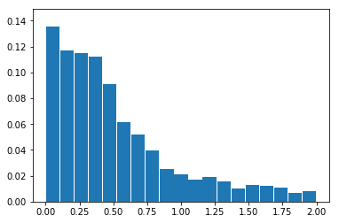

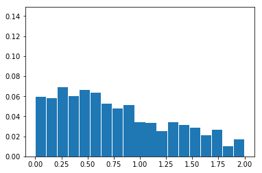

```python
count = len(predicted_df.error_relative)
hist_predicted = np.histogram(predicted_df.error_relative, np.linspace(0, 2, 20))
normalized_hist_predicted = hist_predicted[0]/count
hist_baseline = np.histogram(predicted_df.error_baseline_relative, np.linspace(0, 2, 20))
normalized_hist_baseline = hist_baseline[0]/count
centers = np.convolve(hist_predicted[1], [0.5, 0.5])
centers = centers[1:-1]
plt.bar(centers, normalized_hist_predicted, width=(centers[1]-centers[0])*0.95)
ylim = max(hist_predicted[0]/count) * 1.1
plt.ylim(0, ylim)
plt.show()
plt.bar(centers, normalized_hist_baseline, width=(centers[1]-centers[0])*0.95)
plt.ylim(0, ylim)
plt.show()
```

#### Accumulated

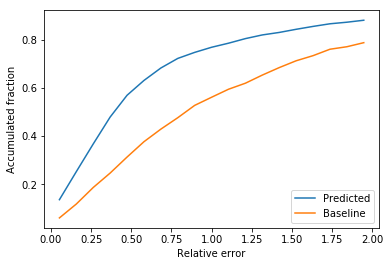

```python
def accumulated_distribution(histogram):
    accumulated = []
    total = 0
    for value in histogram:
        total += value
        accumulated.append(total)
    return accumulated


plt.plot(centers, accumulated_distribution(normalized_hist_predicted), label='Predicted')
plt.plot(centers, accumulated_distribution(normalized_hist_baseline), label='Baseline')
plt.xlabel('Relative error')
plt.ylabel('Accumulated fraction')
plt.legend(loc='lower right')
plt.show()
```

### Joined data summary

```python
predicted_df.describe(percentiles=[0.25, 0.5, 0.75, 0.85, 0.9, 0.95, 0.99])
```

|  | error | error_baseline | error_baseline_relative | error_relative | prediction | sha256_id | target |
| --- | --- | --- | --- | --- | --- | --- | --- |
| count | 1831.000000 | 1831.000000 | 1831.000000 | 1831.000000 | 1831.000000 | 1.831000e+03 | 1831.000000 |
| mean | 46.741096 | 54.427139 | 1.367246 | 0.980547 | 75.042566 | 2.102802e+09 | 67.556783 |
| std | 99.364270 | 111.251272 | 1.580061 | 1.707708 | 85.925744 | 1.233070e+09 | 123.738748 |
| min | 0.005800 | 0.106687 | 0.001464 | 0.000166 | 17.439200 | 2.360530e+05 | 3.000000 |
| 25% | 8.616900 | 25.300000 | 0.431007 | 0.208692 | 36.640000 | 1.003547e+09 | 26.800000 |
| 50% | 19.214000 | 39.996687 | 0.890357 | 0.445714 | 44.771200 | 2.066641e+09 | 38.900000 |
| 75% | 40.289100 | 51.465000 | 1.723384 | 0.957455 | 67.936900 | 3.151859e+09 | 62.775000 |
| 85% | 69.741800 | 57.136687 | 2.481364 | 1.628931 | 106.912900 | 3.621285e+09 | 89.625000 |
| 90% | 106.885800 | 62.986687 | 3.057070 | 2.226640 | 154.570200 | 3.834974e+09 | 116.900000 |
| 95% | 188.401300 | 117.958313 | 4.178484 | 3.866494 | 252.939900 | 4.063829e+09 | 190.945000 |
| 99% | 426.114900 | 512.813313 | 7.118653 | 8.210556 | 462.672280 | 4.238423e+09 | 585.800000 |
| max | 1589.319800 | 2187.123313 | 23.328896 | 19.998267 | 909.762000 | 4.293897e+09 | 2260.110000 |

### Visualize decision tree

```python
# Pull out one tree from the forest
tree = rf.estimators_[0]
# Export the image to a dot file
export_graphviz(tree, out_file = 'tree.dot',
                feature_names = feature_list, rounded = True)
# Use dot file to create a graph
(graph, ) = pydot.graph_from_dot_file('tree.dot')
# Write graph to a png file
graph.write_png('tree.png')
```

[figure not shown]